# 36-315 Lab 06

SOLUTIONS

Due Saturday, October 9, 2021 (12:00pm)

## Lab 06: Trends, Correlations, and Inference for 2D Continuous Data

# Problem 1: Visualizing 2D Quantitative Data with Scatterplots (55 points)

Again we will work with the Food Facts dataset from the previous lab:

```r
food = read.csv("https://raw.githubusercontent.com/zjbranson/315Fall2021/master/food-facts.csv")
```

1. (10pts) Using `ggplot`, create a scatterplot with `fat_100g` on the x-axis and `energy_100g` on the y-axis. If you’re unsure how to do this, consult the Lecture10 R Demo (on Canvas).

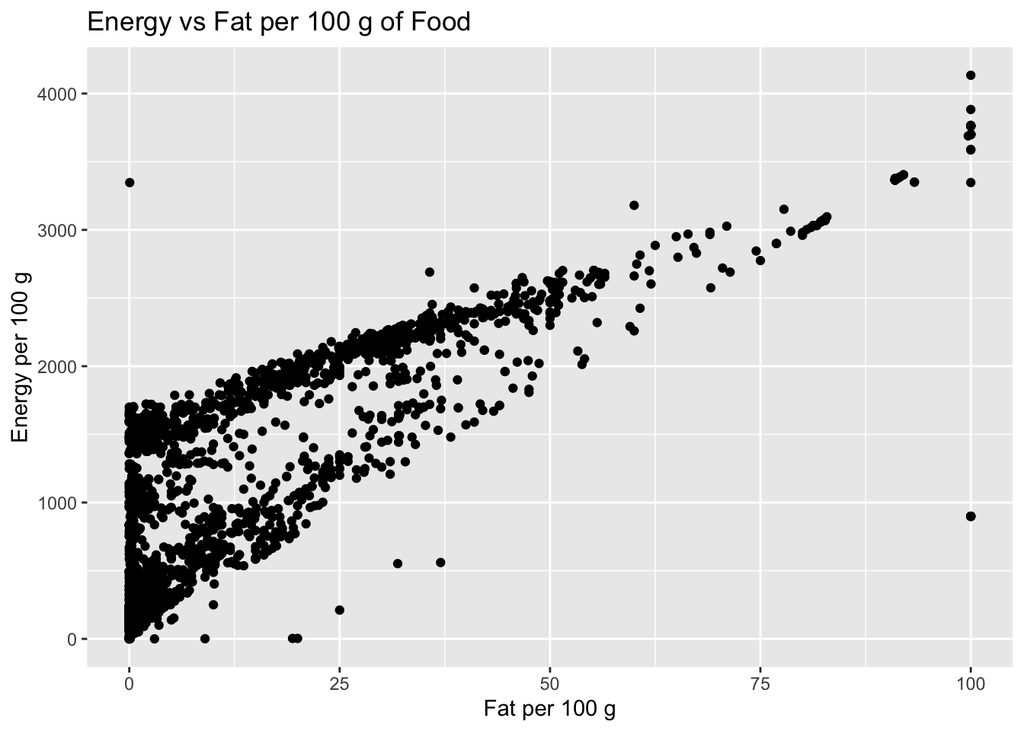

```r
library(tidyverse)
ggplot(food, aes(x = fat_100g, y = energy_100g)) +
  geom_point() +
  labs(x = "Fat per 100 g", y = "Energy per 100 g",
       title = "Energy vs Fat per 100 g of Food")
```

After you’ve made your plot, describe the joint distribution of these two variables in 1-3 sentences. What interesting features do you see? Do the two variables appear to be associated or correlated with each other? Does there appear to be any group structure in the data?

*There appears to be a strong correlation between fat and energy within food products. Higher levels of fat per 100 g are associated with higher levels of energy per 100 g. There appears to be some group structure in the data in the form of two separate linear trends relating fat and energy. Higher fat is associated with higher energy within both trends, but one of the groups has higher levels of energy for any given level of fat.*

2. (5pts) Repeat Part A, but color the points by the food group (`pnns_groups_1`). After you’ve made your graph: Are there particular areas of the graph where certain food groups are common or uncommon? Interpret your findings in the context of the problem.

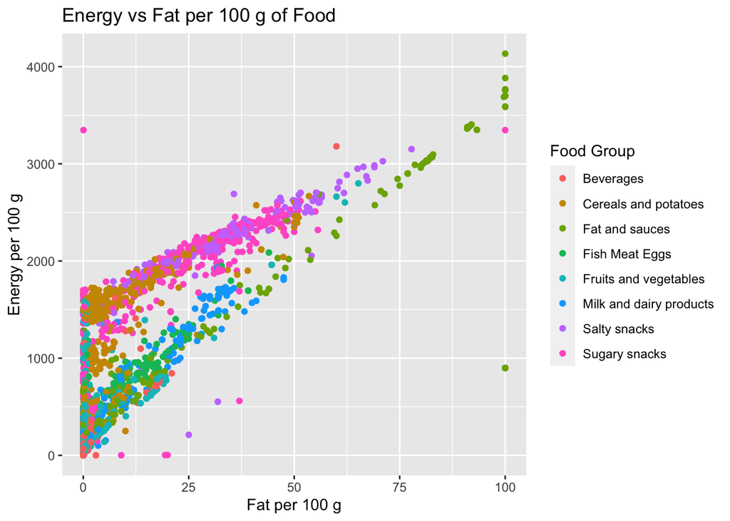

```r
ggplot(food, aes(x = fat_100g, y = energy_100g, col = pnns_groups_1)) +
  geom_point() +
  labs(x = "Fat per 100 g", y = "Energy per 100 g", col = "Food Group",
       title = "Energy vs Fat per 100 g of Food")
```

*Within each food group, higher levels of fat are associated with higher levels of energy. For any given level of fat, salty snacks and sugary snacks tend to have higher levels of energy than fats and sauces, fish/meat/eggs, fruits and vegetables, and milk/dairy products. Fats and sauces tend to have the highest levels of both fat per 100 g and energy per 100 g.*

3. (6pts) Repeat Part B, but this time, facet on the food group instead of coloring the points. In your opinion, is it easier to see food group-specific trends between fat and energy with facetting or with the colors? Do you think this is true generally, or does it depend on the problem?

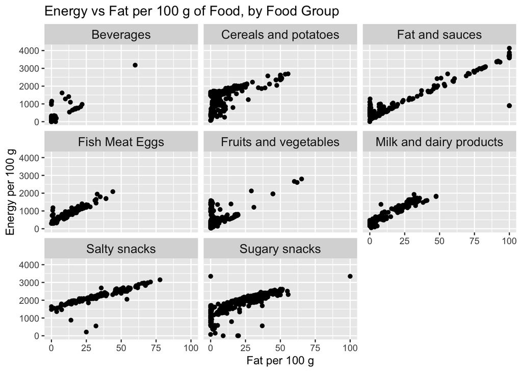

```r
ggplot(food, aes(x = fat_100g, y = energy_100g)) +
  geom_point() +
  facet_wrap(pnns_groups_1 ~ .) +
  theme(strip.text = element_text(size = 12)) +
  labs(x = "Fat per 100 g", y = "Energy per 100 g",
       title = "Energy vs Fat per 100 g of Food, by Food Group",
       col = "Food Group")
```

*In this case, it is easier to see the food group-specific trends between fat and energy per 100 g when faceting on food group than when coloring by food group. We have data on eight different food groups, and there are many observations with similar fat/energy combinations. When coloring by food group, observations from distinct food groups are stacked on top of each other, making it difficult to pick out the trend for any specific food group. When faceting by food group, we can clearly pick out the trend between fat and energy for one food group at a time. The choice to color or facet by group should be problem-specific. For instance, suppose we have data on a small number of well-separated groups. Then plotting all observations on a single set of axes and coloring by group would make it easier to compare trends across groups.*

4. (5pts) Repeat Part B, but this time, change the point shape to correspond to the presence or absence of additives (in addition to coloring the points by food group). In 1-2 sentences, discuss to what extent you can tell if foods with or without additives occur in certain portions of the graph.

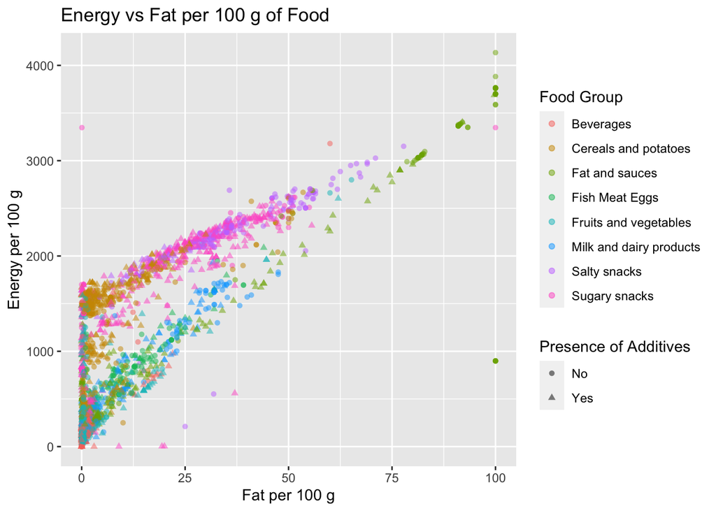

```r
ggplot(food, aes(x = fat_100g, y = energy_100g, col = pnns_groups_1,
                 shape = additives_n)) +
  geom_point(alpha = 0.5) +
  labs(x = "Fat per 100 g", y = "Energy per 100 g", col = "Food Group",
       title = "Energy vs Fat per 100 g of Food",
       shape = "Presence of Additives")
```

*Since there are many overlapping data points on this graph, it is difficult to tell if certain regions contain a majority of food products with additives or without additives. Especially in regions that are dense with points, there appear to be many data points for food products with and without additives stacked on top of each other.*

5. (5pts) Repeat Part D, but this time, change **either** the size of the point or the transparency of the point to correspond to another quantitative variable in the dataset. After you’ve made your plot: Does the variable you chose appear to be associated with either of the other variables you’re plotting here?

*We chose to shade each point based on the food product’s amount of sugar per 100 g. For a given amount of fat, foods that are higher in sugar tend to be higher in energy as well.*

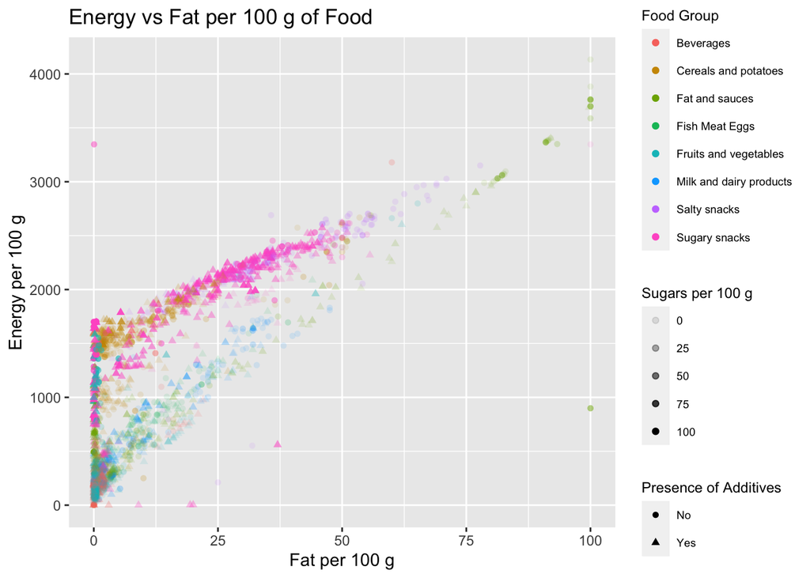

```r
ggplot(food, aes(x = fat_100g, y = energy_100g, col = pnns_groups_1,
                 shape = additives_n, alpha = sugars_100g)) +
  geom_point() +
  theme(legend.title = element_text(size = 9),
        legend.text = element_text(size = 7)) +
  labs(x = "Fat per 100 g", y = "Energy per 100 g", col = "Food Group",
       title = "Energy vs Fat per 100 g of Food",
       shape = "Presence of Additives",
       alpha = "Sugars per 100 g")
```

6. (6pts) Repeat Part A (i.e., make a simple scatterplot with `fat_100g` on the x-axis and `energy_100g` on the y-axis), but this time, add a linear regression line to the plot, with no error bars. Does the line appear to provide a good fit to the variables being plotted here? Why or why not?

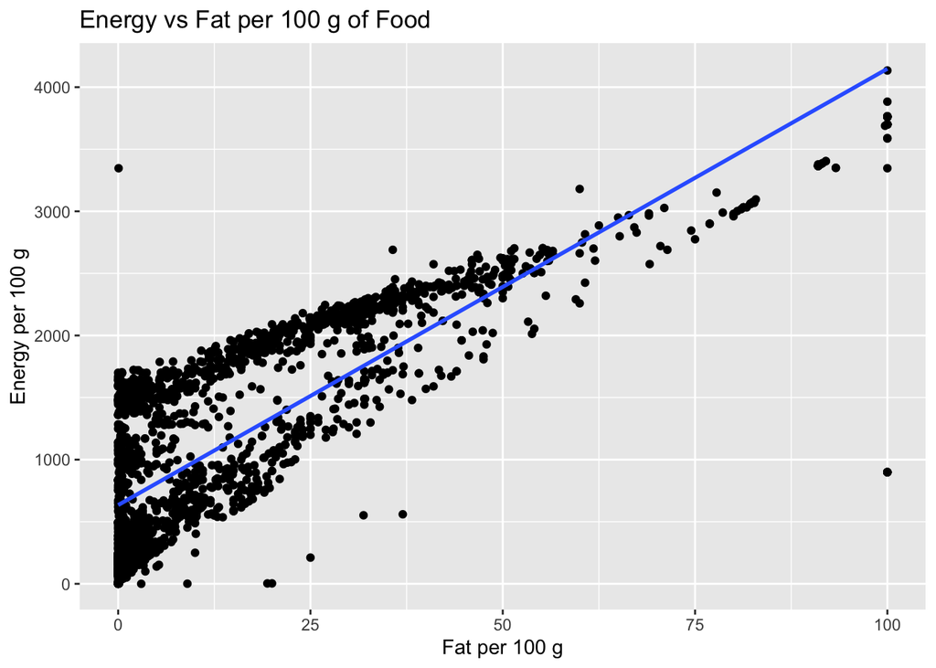

```r
ggplot(food, aes(x = fat_100g, y = energy_100g)) +
  geom_point() +
  labs(x = "Fat per 100 g", y = "Energy per 100 g",
       title = "Energy vs Fat per 100 g of Food") +
  geom_smooth(method = "lm", se = F)
```

7. (8pts) Repeat Part F, but this time, add a nonlinear regression line to the plot (using `"loess"`) instead of a linear regression line, again with no error bars. Does the non-linear regression model appear to provide a better or worse fit than the linear model in Part G? Why? Are there any particular areas of the graph where the nonlinear regression line does not closely match the underlying data? If so, where?

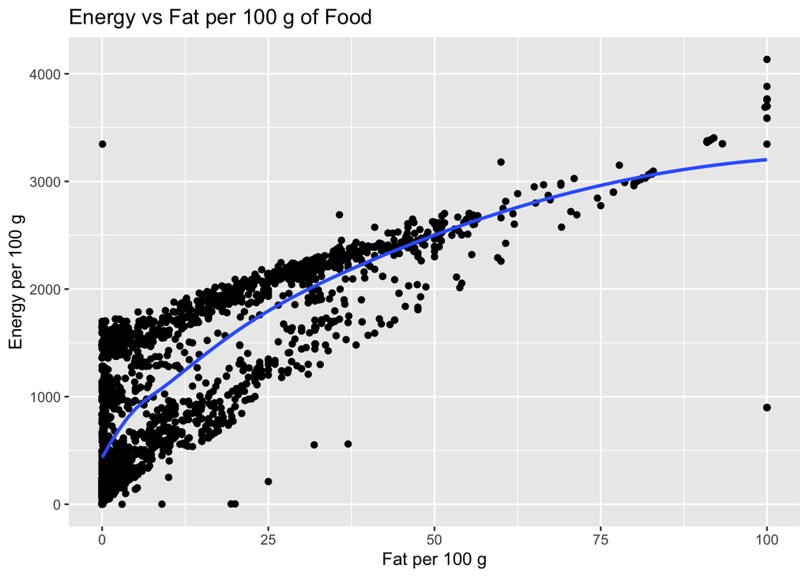

```r
ggplot(food, aes(x = fat_100g, y = energy_100g)) +
  geom_point() +
  labs(x = "Fat per 100 g", y = "Energy per 100 g",
       title = "Energy vs Fat per 100 g of Food") +
  geom_smooth(method = "loess", se = F)
```

*The non-linear trend curve is not clearly a better fit than the linear model. The underlying trend appears to be linear (perhaps two separate linear trends), whereas the non-linear curve seems to capture a square root trend. The curve does not closely match the underlying data for observations with more than 82 g of fat. There are some influential outliers with 100 g of fat and fewer than 1000 calories (energy). These outliers pull the line down, so that the curve predicts energy levels below the observed energy levels for all other outliers with over 82 g of fat.*

8. (5pts) Repeat Part G, but this time, color the points by their food group (similar to Part B). Be sure to have only a single non-linear regression line in the plot. To do this, you’ll need to specify the `x` and `y` aesthetics in the initial call to `aes()` in `ggplot()`, and the `color` aesthetic in the call to `geom_point()`.

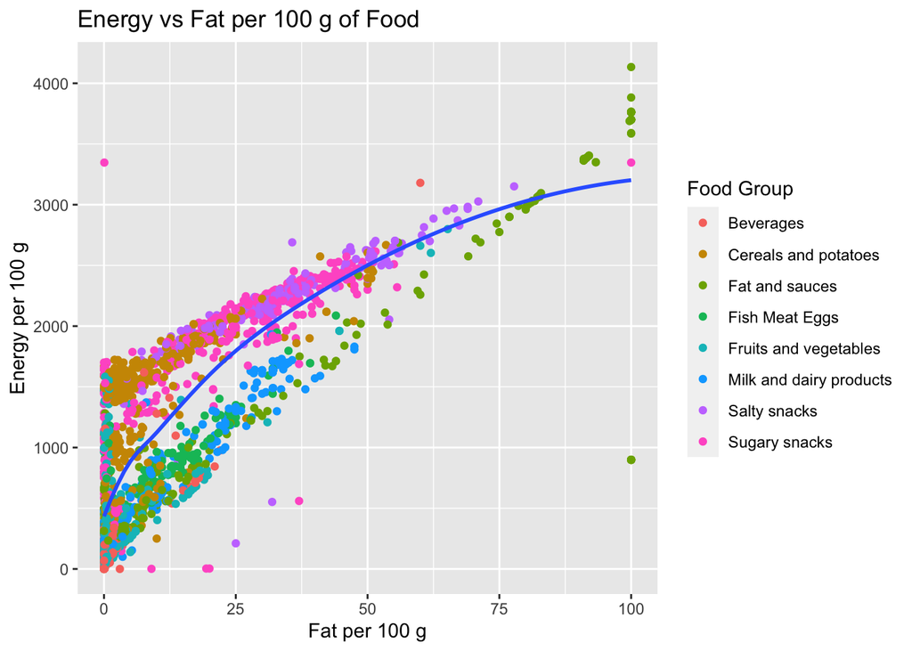

```r
ggplot(food, aes(x = fat_100g, y = energy_100g)) +
  geom_point(aes(color = pnns_groups_1)) +
  labs(x = "Fat per 100 g", y = "Energy per 100 g", col = "Food Group",
       title = "Energy vs Fat per 100 g of Food") +
  geom_smooth(method = "loess", se = F)
```

1. (5pts) Repeat Part H, but this time, add several non-linear regression lines to the plot – one for each of the food groups. To do this, just move the specification of the `color` aesthetic from `geom_point()` to the original call to `aes()` in `ggplot()`.

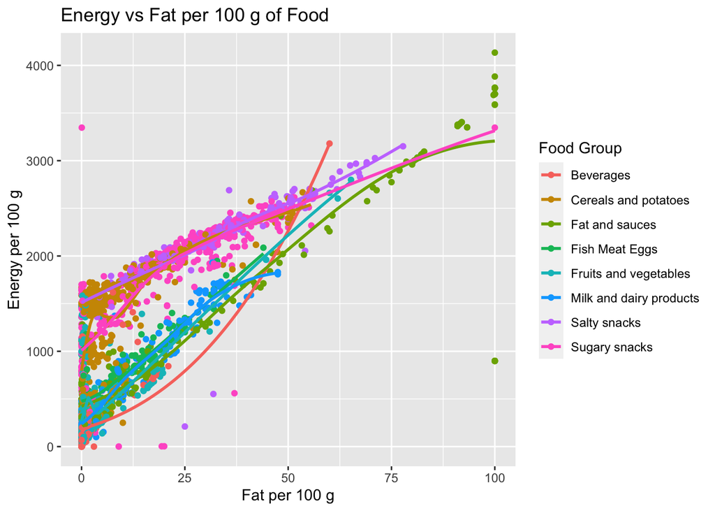

```r
ggplot(food, aes(x = fat_100g, y = energy_100g, color = pnns_groups_1)) +
  geom_point() +
  labs(x = "Fat per 100 g", y = "Energy per 100 g", col = "Food Group",
       title = "Energy vs Fat per 100 g of Food") +
  geom_smooth(method = "loess", se = F)
```

# Problem 2: Correlations and Inference (30 points)

1. (6 points) The `cor()` function returns the correlation between two variables; the notation `cor(x, y)` denotes the correlation between `x` and `y`. Using this, answer the following: What is the correlation of the `fat_100g` and `energy_100g` variables?

*The correlation between `fat_100g` and `energy_100g` is approximately 0.798:*

```r
cor(x = food$fat_100g, y = food$energy_100g)
```

```
## [1] 0.798035
```

After you’ve done that, uncomment the following code, and answer the following questions:

- What does the following code do?
- Which pair of two unique variables has the strongest positive correlation?
- Which pair of variables below has the strongest negative correlation?

```r
food %>%
  select(fat_100g, energy_100g, sugars_100g, proteins_100g) %>%
  cor
```

```
##                  fat_100g energy_100g sugars_100g proteins_100g
## fat_100g       1.00000000   0.7980350 -0.01902115     0.2175568
## energy_100g    0.79803503   1.0000000  0.24958140     0.3440504
## sugars_100g   -0.01902115   0.2495814  1.00000000    -0.1956644
## proteins_100g  0.21755681   0.3440504 -0.19566442     1.0000000
```

*This code computes a correlation matrix with all pairwise correlations between `fat_100g`, `energy_100g`, `sugars_100g`, and `proteins_100g`.*

*`fat_100g` and `energy_100g` have the strongest positive correlation.*

*`sugars_100g` and `proteins_100g` have the strongest negative correlation.*

2. (4 points) As discussed in lecture, we write `lm(y~x, data = data)` to fit a linear regression of `y` on `x`. Here, `y` is considered the outcome, and `x` is considered the covariate. (Within `lm()`, the `data` argument isn’t necessary if `x` and `y` are already defined outside of a dataset.)

In this part, define a variable, `linReg`, as a linear regression between `fat_100g` and `energy_100g` (where `energy_100g` is treated as the outcome). Then, write `summary(linReg)`, and look for the number called the “Multiple R-squared.” Compute the square-root of this number, and compare it with the number you found in Part A.

*Below we fit a linear regression between `energy_100g` and `fat_100g`:*

```r
linReg = lm(energy_100g~fat_100g, data = food)
summary(linReg)
```

```
##
## Call:
## lm(formula = energy_100g ~ fat_100g, data = food)
##
## Residuals:
##     Min      1Q  Median      3Q     Max
## -3249.0  -450.3  -177.9   494.0  2710.7
##
## Coefficients:
##             Estimate Std. Error t value Pr(>|t|)
## (Intercept) 634.2701    13.0600   48.57   <2e-16 ***
## fat_100g     35.1372     0.5375   65.38   <2e-16 ***
## ---
## Signif. codes:  0 '***' 0.001 '**' 0.01 '*' 0.05 '.' 0.1 ' ' 1
##
## Residual standard error: 530.2 on 2437 degrees of freedom
## Multiple R-squared:  0.6369, Adjusted R-squared:  0.6367
## F-statistic:  4274 on 1 and 2437 DF,  p-value: < 2.2e-16
```

```r
sqrt(0.6369)
```

```
## [1] 0.7980601
```

*We see that the square-root of $R^2$ is equal to the correlation between `energy_100g` and `fat_100g`(from Part A). (They actually do equal exactly, but there is a slight discrepancy between the number here and the number in Part A due to rounding error.)*

3. (10pts) Now consider the following plot:

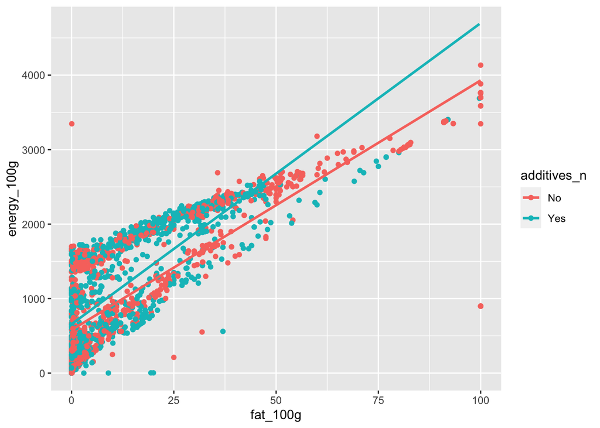

```r
library(tidyverse)
ggplot(food, aes(x = fat_100g, y = energy_100g, color = additives_n)) + geom_point() + geom_smooth(method = "lm", se = FALSE)
```

The above scatterplot displays a linear regression for two subsets of data: One where `additives_n = "No"` (the red line) and one where `additives_n = "Yes"` (the blue line). As discussed in class, each regression line can be described by an intercept and a slope.

Now, consider the following linear regression output:

```r
summary(lm(energy_100g ~ fat_100g*additives_n, data = food))
```

```
##
## Call:
## lm(formula = energy_100g ~ fat_100g * additives_n, data = food)
##
## Residuals:
##     Min      1Q  Median      3Q     Max
## -3030.8  -426.1  -167.1   458.4  2766.6
##
## Coefficients:
##                         Estimate Std. Error t value Pr(>|t|)
## (Intercept)             578.4644    16.9833  34.061  < 2e-16 ***
## fat_100g                 33.5129     0.6136  54.618  < 2e-16 ***
## additives_nYes           78.1142    26.5510   2.942  0.00329 **
## fat_100g:additives_nYes   6.9130     1.2019   5.751 9.95e-09 ***
## ---
## Signif. codes:  0 '***' 0.001 '**' 0.01 '*' 0.05 '.' 0.1 ' ' 1
##
## Residual standard error: 520 on 2435 degrees of freedom
## Multiple R-squared:  0.651,  Adjusted R-squared:  0.6505
## F-statistic:  1514 on 3 and 2435 DF,  p-value: < 2.2e-16
```

This is the interactive regression model that’s being plotted above. Given this output, answer the following questions. For each question, briefly explain how you arrived at your answer.

*For this part, it can be helpful to write out the prediction equation that’s being produced in the above output:*

$$\widehat{\text{energy}} = \hat{\beta}_0 + \hat{\beta}_F \cdot \text{fat} + \hat{\beta}_A \cdot I_A + \hat{\beta}_{FA} \cdot \text{fat} \cdot I_A$$

*where $I_A = 1$ if a food has `additives_n = "Yes"` and $I_F = 0$ if a food has `additives_n = "No"`. Given the above, we can write out the prediction equation for foods with and without additives:*

- *Additives:* $\widehat{\text{energy}} = \hat{\beta}_0 + \hat{\beta}_F \cdot \text{fat} + \hat{\beta}_A + \hat{\beta}_{FA} \cdot \text{fat} = (\hat{\beta}_0 + \hat{\beta}_A) + (\hat{\beta}_F + \hat{\beta}_{FA}) \cdot \text{fat}$
- *No Additives:* $\widehat{\text{energy}} = \hat{\beta}_0 + \hat{\beta}_F \cdot \text{fat}$

*Given this, and the output above (which gives us estimates for all four $\beta$ parameters), we can quickly answer the following questions:*

- For `additives_n = "No"` foods (i.e., the red regression line), what is the estimated intercept?

*The estimated intercept is $\hat{\beta}_0 = 578.4644$.*

- For `additives_n = "No"` foods (i.e., the red regression line), what is the estimated slope?

*The estimated slope is $\hat{\beta}_F = 33.5129$.*

*The estimated intercept is $\hat{\beta}_0 + \hat{\beta}_A = 578.4644 + 78.1142 = 656.5786$.*

*The estimated slope is $\hat{\beta}_F + \hat{\beta}_{FA} = 33.5129 + 6.9130 = 40.4259$.*

**Note**: This question might be tricky if you haven’t seen linear regression before, so please ask us for help if you’re confused here!

4. (5pts) Given the regression output in Part C, answer the following:

*Using the prediction equation we wrote out in the previous part, we can plug in values for `fat_100g` and `additives_n` to answer the following questions.*

- What is the estimated mean `energy_100g` when `fat_100g = 100` and `additives_n = "No"`?

*$578.4644 + 100 \cdot 33.5129 = 3929.754$*

- What is the estimated mean `energy_100g` when `fat_100g = 100` and `additives_n = "Yes"`?

*$656.5786 + 100 \cdot 40.4259 = 4699.169$*

These questions basically boil down to: What are the right endpoints of the red and blue lines in the plot? However, you should be able to compute exact numbers for this question.

5. (5pts) In the output in Part C, you should see that the term `fat_100g:additives_nYes` has a positive estimate (6.9130) and a very small p-value. In 1-2 sentences, answer the following: What is your interpretation of this finding, within the context of the graph in Part C?

*The coefficient for `fat_100g:additives_nYes` corresponds to the change in slope between foods without additives (`additives_n = "No"`) and foods with additives (`additives_n = "Yes"`). From the output, we see that this estimated change is positive and statistically significant, in the sense that we reject the null hypothesis that this population-level mean change in slopes is equal to 0. Thus, we can interpret this finding as: The slope of the blue line is steeper than the slope of the red line, to a statistically significant degree.*

# Problem 3: Plotting Subsets of Data (15 points)

Often we want to focus our graphs and analyses on particular subsets of the data - this has already come up a few times in the class. To get particular subsets of data in `R`, the function `subset` is very useful. I’ve actually used the `subset()` function a fair number of times already in this class (in labs/homeworks).

Using the `subset` function, create two datasets: `sugary`, which contains foods whose food group is “Sugary snacks”, and `cerealPotato`, which contains foods whose food group is “Cereals and potatoes”. (No, I don’t know why these people lumped cereals and potatoes together.) Then, for each of these subsets, create a scatterplot with `fat_100g` on the x-axis and `energy_100g` on the y-axis, and add a nonlinear trend line (`"loess"`) to each of these plots (no standard errors added).

In 1-2 sentences, compare and contrast the trend lines you see.

*The following code creates the datasets `sugary` and `cerealPotato`, which contain only “Sugar snacks” and “Cereals and potatoes”, respectively.*

```r
sugary = subset(food, pnns_groups_1 == "Sugary snacks")
cerealPotato = subset(food, pnns_groups_1 == "Cereals and potatoes")
```

*Then, we can create a scatterplot for each of these datasets, with a nonlinear trend added to each plot:*

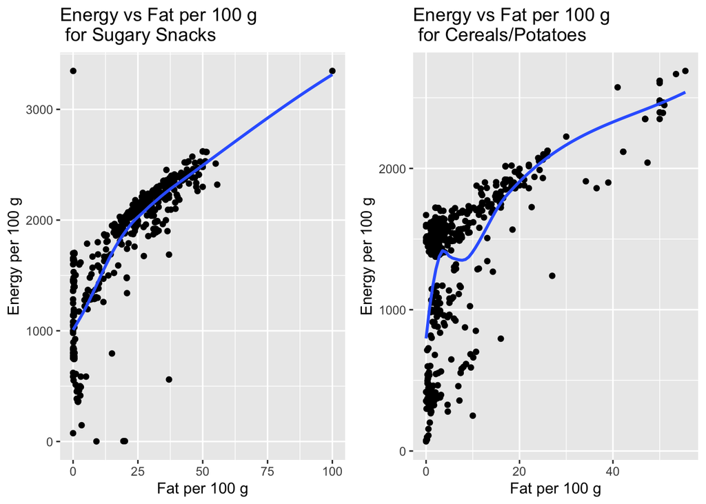

```r
library(gridExtra)
sugarPlot = ggplot(sugary, aes(x = fat_100g, y = energy_100g)) +
  geom_point() +
  geom_smooth(method = "loess", se = FALSE) +
  labs(x = "Fat per 100 g", y = "Energy per 100 g",
       title = "Energy vs Fat per 100 g \n for Sugary Snacks")
cpPlot = ggplot(cerealPotato, aes(x = fat_100g, y = energy_100g)) +
  geom_point() +
  geom_smooth(method = "loess", se = FALSE) +
  labs(x = "Fat per 100 g", y = "Energy per 100 g",
       title = "Energy vs Fat per 100 g \n for Cereals/Potatoes")
grid.arrange(sugarPlot, cpPlot, nrow = 1)
```

*A few observations can be made from the above plots. First, by comparing the y-axes, we can see that sugary snacks tend to have more energy (in terms of calories) than the cereals-and-potatoes dataset. After accounting for this difference, it appears that the trends for both datasets are quite similar. For the cereals-and-potatoes dataset, we can see that there is a bit more fluctuation in this trend - this is because there is (compared to the sugary snacks dataset) a lot more variation in `energy_100g` (this makes sense, because the cereals-and-potatoes subset probably contains a more heterogeneous set of foods than the sugary snacks subset).*